# Calculating the Harmful Effects of Weather

## Synopsis

Preparing for harmful and damaging weather events will require predicting the frequency of events and the amount of damage caused given the distribution of each event across the country. Historically, tornadoes are the most harmful weather event, and occur most frequently in Texas and other states in the middle of the country. Floods cause the most property and crop damage. This analysis lays the groundwork for preparing for future weather events.

## Introduction

This analysis addresses the following questions:

1. Across the U.S., which types of weather events are most harmful with respect to population health?
2. Across the U.S., which types of weather events have the greatest economic consequences?

The objective of this analysis is to prepare for severe weather events and prioritize resources for different types of events. To this end, the analysis includes the geographic distribution and reviews the trends over time of the harmful weather events.

The data come from the NOAA storm database, which tracks characteristics of major storms and weather events in the U.S. including when and where they occur, as well as estimates of any fatalities, injuries, and property damage. The data consist of 902,297 observations of 37 variables.

## Data Processing

```r
library(lubridate)
library(stats)
library(Hmisc)
library(ggplot2)
```

### Downloading the Data

```r
# download storm data
fileurl <- "https://d396qusza40orc.cloudfront.net/repdata%2Fdata%2FStormData.csv.bz2"
filename <- "repdata-data-StormData.csv.bz2"
downloadData <- function() {

        if (!file.exists(filename)) {
                download.file(fileurl, dest=filename, method="curl")
        }
        con <- bzfile(filename, open = "r")
        close(con)
        data <- read.csv(con <- bzfile(filename, open = "r"), header = TRUE, stringsAsFactors = FALSE)
        close(con)
        names(data) <- tolower(names(data))
        data
}
```

The second download function creates a data set of the 48 official NOAA weather event types, as listed in page 6 of the [National Weather Service’s Storm Data Documentation](https://d396qusza40orc.cloudfront.net/repdata%2Fpeer2_doc%2Fpd01016005curr.pdf), and two sets of strings that will be used to clean the evtype variable in the storm data set.

```r
data <- downloadData()
data <- data[, c(2, 7:8, 23:28)]

# download official NOAA storm data event types
file2url <- "https://raw.githubusercontent.com/rganzi/stormdata1/master/evtype_off.csv"
file2name <- "evtype_off.csv"
evtype.download <- function() {
        if (!file.exists(file2name)) {
                download.file(file2url, dest = file2name, method = "curl")
        }
        evtype.off <- read.csv(file2name, header = TRUE, colClasses = "character", na.strings = "")
}

evtype.off <- evtype.download()
```

### Cleaning the Data

Since the objective of the analysis is to specify harmful and damaging weather events, it was important that the event types variable be standardized to only include the 48 official types. In the original data set, there are 985 event types. Using the `evtype.off` data set and regular expressions, I replaced the unofficial types with official ones, if possible. When all the non-standard types are removed, 890,572 observations remain.

```r
# replace unofficial event types
for (i in 1:length(evtype.off$evtype)) {
        logic.vect <- grepl(evtype.off$match1[i], data$evtype, perl=TRUE) |
                grepl(evtype.off$match2[i], data$evtype, perl=TRUE)
        data$evtype[logic.vect] <- evtype.off$evtype[i]
}

# only include official NOAA storm data event types
stormdata <- data[toupper(data$evtype) %in% toupper(evtype.off$evtype), ]
stormdata$evtype <- as.factor(tolower(stormdata$evtype))
#rm(data)

# Date class
stormdata$bgn_date <- as.Date(stormdata$bgn_date, format = "%m/%d/%Y")
```

I did not remove the non-standard, numerical exponent values. The standard letter values, “H”, “K”, “M”, and “B” were replaced by “2”, “3”, “6”, and “9,” respectively. All “NA” values were converted to “0” so to have no effect when multiplying with the property and crop damage variables.

```r
# replace abbreviations for *exp columns
abbs <- c("H", "K", "M", "B")
digs <- c(2, 3, 6, 9)

for(i in 1:4) {
        stormdata$propdmgexp <- gsub(abbs[i], digs[i], stormdata$propdmgexp, ignore.case = TRUE)
        stormdata$cropdmgexp <- gsub(abbs[i], digs[i], stormdata$cropdmgexp, ignore.case = TRUE)
}

stormdata$propdmgexp <- as.integer(stormdata$propdmgexp)
stormdata$propdmgexp[is.na(stormdata$propdmgexp)] <- 0

stormdata$cropdmgexp <- as.integer(stormdata$cropdmgexp)
stormdata$cropdmgexp[is.na(stormdata$cropdmgexp)] <- 0

# new variables for calculated damage values, including total damage
stormdata$propdmg <- stormdata$propdmg * 10^stormdata$propdmgexp
stormdata$cropdmg <- stormdata$cropdmg * 10^stormdata$cropdmgexp
stormdata$totaldmg <- stormdata$propdmg + stormdata$cropdmg
# remove *exp columns
stormdata <- stormdata[, -c(7,9)]
```

## Results

The Results section consists of four functions and their outputs. The first gives the sum of total harm or damage done over the entire data set, split by weather event type. The second shows the geographic distribution of total harm or damage done over the period. The third calculates the frequency of a particular weather event over time. And the fourth shows the geographic distribution of individual weather events.

### 1. Total Harm and Damage Done

The first function gives the sum of the harm and damage variables by event type for the entire data set (across all years and geography).

```r
# tables of total damage by event type
total.cost <- function(n, cat = c("injuries", "fatalities", "propdmg", "cropdmg", "totaldmg")) {
        byevent <- split(stormdata, stormdata$evtype)
        df <- data.frame()
        for(i in 1:length(names(byevent))) {
                total <- sum(byevent[[i]][, cat])
                df <- rbind(df, total)
        }
        df <- cbind(names(byevent), df)
        names(df) <- c("evtype", cat)
        df <- df[order(df[cat], decreasing = TRUE), ]
        df[1:n, ]
}
```

The following tables rank the harm and damage data by most harmful or damaging event type.

**Table 1. Total injuries by weather event type - Top 6**

```r
# injuries
total.cost(6, "injuries")
```

```
##               evtype injuries
## 36           tornado    91407
## 35 thunderstorm wind     9493
## 14             flood     6789
## 11    excessive heat     6525
## 28         lightning     5232
## 19              heat     2100
```

Total tornado injuries are nearly an order of magnitude more frequent than the next most common cause of injury (thunderstorm wind).

**Table 2. Total fatalities by weather event type - Top 6**

```r
# fatalities
total.cost(6, "fatalities")
```

```
##               evtype fatalities
## 36           tornado       5636
## 11    excessive heat       1903
## 13       flash flood       1035
## 19              heat        937
## 28         lightning        817
## 35 thunderstorm wind        753
```

Tornadoes are significantly more fatal than other types of harmful weather events, like excessive heat.

**Table 3. Total property and crop damage by weather event type - Top 6**

```r
# total property dmg (including crop dmg)
total.cost(6, "totaldmg")
```

```
##                 evtype  totaldmg
## 14               flood 1.503e+11
## 24 hurricane (typhoon) 9.076e+10
## 36             tornado 5.742e+10
## 33    storm surge/tide 4.797e+10
## 13         flash flood 1.912e+10
## 18                hail 1.876e+10
```

Floods cause the most total property and crop damage, followed by hurricanes (hurricane (typhoon)).

### 2. Geographic Distribution of Harm and Damage Done

These weather events do not affect all areas of the country equally. And a policymaker preparing for weather events will likely want to know where funding will need to be dispersed. The second function creates a map of harm or damage done by state.

```r
# maps of total harm or damage by state
map.dmg <- function(dmg = c("injuries", "fatalities", "propdmg", "cropdmg", "totaldmg")) {
        library(maps)
        library(scales)
        library(mapproj)

        data(state)
        data.dmg = data.frame()
        for (i in 1:50) {
                state.dmg <- stormdata[stormdata$state == state.abb[i], ]
                sum.dmg <- sum(state.dmg[, dmg])
                data.dmg <- rbind(data.dmg, sum.dmg)
        }
        data.dmg <- cbind(tolower(state.name), data.dmg)
        names(data.dmg) <- c("state", "damage")

        #map data
        state_df <- map_data("state")
        map.data <- merge(state_df, data.dmg, by.x = "region", by.y = "state")
        map.data <- map.data[order(map.data$order), ] ##re-order

        #cut count var for scale
        map.data$cut = cut(map.data$damage, breaks = c(seq(0, max(map.data$damage) * (8/9),
                                                        by = max(map.data$damage) / 8),
                                                        max(map.data$damage)))

        #plot
        ggplot(map.data, aes(long, lat, group = group)) +
                geom_polygon(data = state_df, colour = "#333333", fill = "#D0D0D0", size = 0.3) +
                geom_polygon(aes(fill = cut)) +
                scale_fill_brewer(palette = "PuRd", guide = guide_legend(title = capitalize(dmg))) +
                geom_path(data = state_df, colour = "#666666", size = 0.1) +
                coord_map("lagrange") +
                labs(title = paste(capitalize(dmg), "by State, 1950-2012", sep = " "), x="", y="") +
                theme_bw()
}
```

Texas and Illinois suffer the most fatalities from weather events followed by Missouri, Alabama, and Florida.

**Fig. 1 Fatalities due to all weather events by state, 1950-2012**

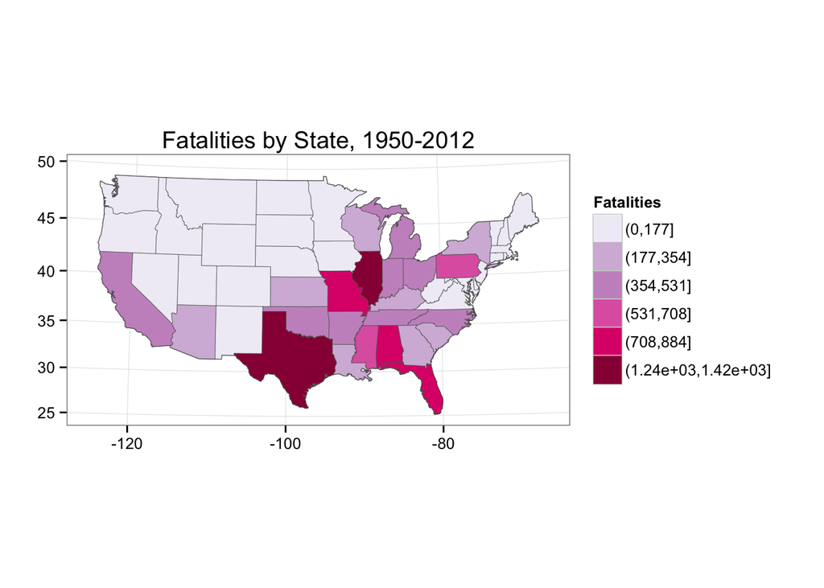

```r
map.dmg("fatalities")
```

### 3. Trends in Weather Events

Just because a weather event has caused harm or damage in the past does not mean it will do so in the future. Similarly, certain types of weather events may increase in frequency. The third function plots a count of weather events, grouped by year, over the period of the data set.

```r
# time-series function for event.type frequency
ts <- function(type = evtype.off$evtype) {
        years <- unique(year(stormdata$bgn_date))
        counts <- data.frame()

        for(i in 1:length(years)) {
                count <- nrow(stormdata[year(stormdata$bgn_date) == years[i] &
                                                stormdata$evtype == type, ])
                counts <- rbind(counts, c(years[i], count))
        }
        names(counts) <- c("year", "count")
        counts
}
```

```r
# plot function for ts
plot.ts <- function(evtype = evtype.off$evtype) {
        set <- ts(evtype)
        #tmod <- lm(count ~ year, data = set)

        #time-series plot
        t <- ggplot(data = set, aes(y = count, x = year))
        t + geom_point(colour = "blue") +
                #geom_line(data = tmod, aes(x = year, y = tmod$fitted)) +
                ggtitle(paste(capitalize(evtype), "Frequency", sep = " ")) +
                xlab("Year") +
                ylab(paste(capitalize(evtype), "Count", sep = " ")) +
                theme_bw()
}
```

The frequency of tornadoes appears to be increasing dramatically. This trend is likely a combination of real changing weather patterns and inconsistency in reporting practices.

**Fig. 2 Tornado frequency, 1950-2012**

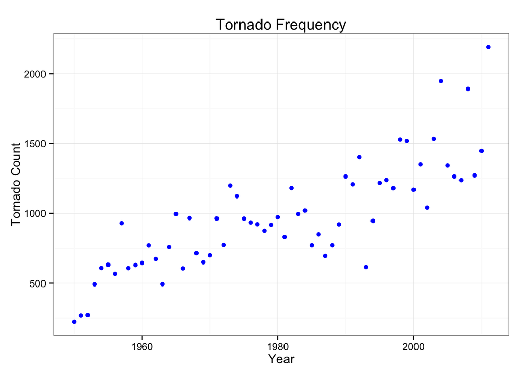

```r
plot.ts("tornado")
```

### 4. Geographic Distribution of Weather Events

Finally, in order to prepare for future weather aid requirements, it is necessary to predict which areas will be affected the most by future changes in harmful and damaging weather events. The fourth function creates a map of counts of individual types of weather events by state.

```r
# geographic distribution of event types
map.evtype <- function(evtype = evtype$evtype) {
        library(maps)
        library(scales)
        library(mapproj)

        data(state)
        # evtype data
        evtype.data <- data.frame()
        for (i in 1:length(state.abb)) {
                subset.evtype <- stormdata[stormdata$evtype == evtype, ]
                sum.states <- sum(subset.evtype$state == state.abb[i])
                evtype.data <- rbind(evtype.data, sum.states)
        }
        evtype.data <- cbind(tolower(state.name), evtype.data)
        names(evtype.data) <- c("state", "count")

        # map data
        state_df <- map_data("state")
        map.data <- merge(state_df, evtype.data, by.x = "region", by.y = "state")
        map.data <- map.data[order(map.data$order), ] # re-order

        # cut count var for scale
        map.data$cut = cut(map.data$count, breaks = seq(0, max(map.data$count),
                by = max(map.data$count) / 9))

        # plot
        ggplot(map.data, aes(long, lat, group = group)) +
                geom_polygon(data = state_df, colour = "#333333", fill = "#D0D0D0", size = 0.3) +
                geom_polygon(aes(fill = cut)) +
                scale_fill_brewer(palette = "PuRd", guide = guide_legend(title = "Count")) +
                geom_path(data = state_df, colour = "#666666", size = 0.1) +
                coord_map("lagrange") +
                labs(title = paste(capitalize(evtype), "Counts by State", sep = " "), x="", y="") +
                theme_bw()
}
```

Tornadoes have occurred most frequently in Texas, with Kansas and Oklahoma following in prevalence.

**Fig. 3 Tornado reports by state, 1950-2012**

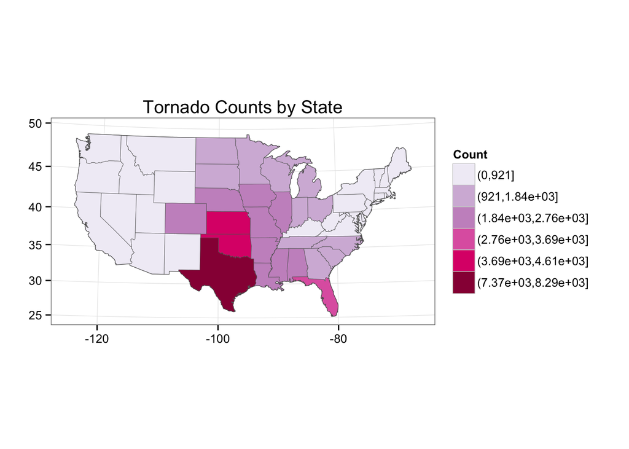

```r
map.evtype("tornado")
```

## Discussion

The calculations of total harm and damage, frequencies, and geographic distributions all rely on the complete reporting of weather events. Unfortunately, a cursory look at the event trends casts serious doubt that every event was reported. More recent data appears to be more complete, and the calculations and rankings may be more accurate if the analysis were limited to these observations.

## Conclusion

Preparing for future harmful and damaging weather events will require predicting the frequency of events and the amount of damage caused given the distribution of each event across the country. This analysis lays the groundwork for such a preparation.